# Peer-graded Assignment: Course Project 1

### Loading and preprocessing the data

1. Load the data (i.e. read.csv())

```r
activity <- read.csv("/Users/yehudibaptiste/downloads/activity.csv", as.is = TRUE)
```

2. Process/transform the data (if necessary) into a format suitable for your analysis

```r
clean_data <- good_act <- activity[complete.cases(activity), ]
```

3. Inspect the clean data

```r
summary(clean_data)
```

```
     steps            date              interval
 Min.   :  0.00   Length:15264       Min.   :   0.0
 1st Qu.:  0.00   Class :character   1st Qu.: 588.8
 Median :  0.00   Mode  :character   Median :1177.5
 Mean   : 37.38                      Mean   :1177.5
 3rd Qu.: 12.00                      3rd Qu.:1766.2
 Max.   :806.00                      Max.   :2355.0
```

```r
head(clean_data)
```

|  | steps | date | interval |
| --- | --- | --- | --- |
| 289 | 0 | 2012-10-02 | 0 |
| 290 | 0 | 2012-10-02 | 5 |
| 291 | 0 | 2012-10-02 | 10 |
| 292 | 0 | 2012-10-02 | 15 |
| 293 | 0 | 2012-10-02 | 20 |
| 294 | 0 | 2012-10-02 | 25 |

### What is mean total number of steps taken per day?

1. Calculate the total number of steps taken per day

```r
daily_steps <- aggregate(steps ~ date, clean_data, sum)
```

2. Make a histogram of the total number of steps taken each day

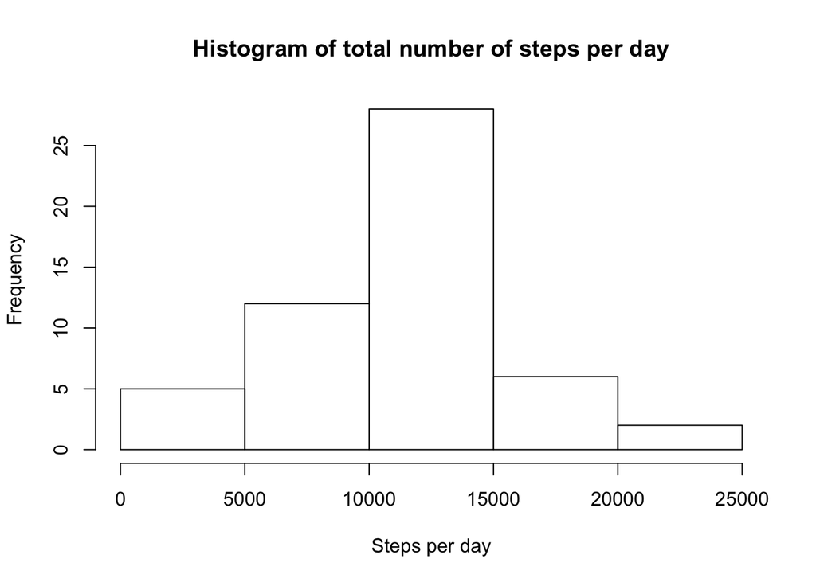

```r
hist(daily_steps$steps, main = "Histogram of total number of steps per day", xlab = "Steps per day")
```

3. Calculate and report the mean and median of the total number of steps taken per day

```r
(mean(daily_steps$steps))
```

```
[1] 10766.19
```

```r
(median(daily_steps$steps))
```

```
[1] 10765
```

### What is the average daily activity pattern?

1. Make a time series plot (i.e. type=“l”) of the 5-minute interval (x-axis) and the average number of steps taken, averaged across all days (y-axis)

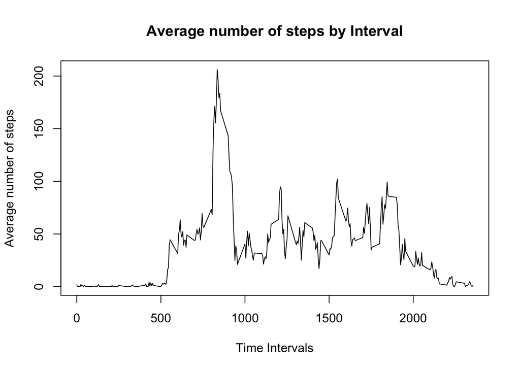

```r
average_daily_steps_interval <- aggregate(steps ~ interval, clean_data, mean)
plot(average_daily_steps_interval$interval, average_daily_steps_interval$steps, type='l', col=1, main="Average number of steps by Interval", xlab="Time Intervals", ylab="Average number of steps")
```

2. Which 5-minute interval, on average across all the days in the dataset, contains the maximum number of steps?

```r
highest_average_steps_interval <- which.max(average_daily_steps_interval$steps)
average_daily_steps_interval[highest_average_steps_interval, ]$interval
```

```
[1] 835
```

```r
average_daily_steps_interval[highest_average_steps_interval, ]$steps
```

```
[1] 206.1698
```

### Imputing missing values

1.Calculate and report the total number of missing values in the dataset (i.e. the total number of rows with NAs)

```r
missingdata <- activity[!complete.cases(activity), ]
nrow(missingdata)
```

```
[1] 2304
```

2. Devise a strategy for filling in all of the missing values in the dataset. The strategy does not need to be sophisticated. For example, you could use the mean/median for that day, or the mean for that 5-minute interval, etc.
3. Create a new dataset that is equal to the original dataset but with the missing data filled in.

```r
for (i in 1:nrow(activity)) {
    if(is.na(activity$steps[i])) {
        val <- average_daily_steps_interval$steps[which(average_daily_steps_interval$interval == activity$interval[i])]
        activity$steps[i] <- val
    }
}
```

[figure not shown]

```r
hist(new_daily_steps$steps, main = "Histogram of total number of steps per day (with new data)", xlab = "Steps per day")
```

[output not shown]

```r
mean(new_daily_steps$steps)
```

[output not shown]

```r
median(new_daily_steps$steps)
```

[output not shown]

### Are there differences in activity patterns between weekdays and weekends?

1. Create a new factor variable in the dataset with two levels – “weekday” and “weekend” indicating whether a given date is a weekday or weekend day.

```r
week_day <- function(date_val) {
    wd <- weekdays(as.Date(date_val, '%Y-%m-%d'))
    if  (!(wd == 'Saturday' || wd == 'Sunday')) {
        x <- 'Weekday'
    } else {
        x <- 'Weekend'
    }
    x
}
```

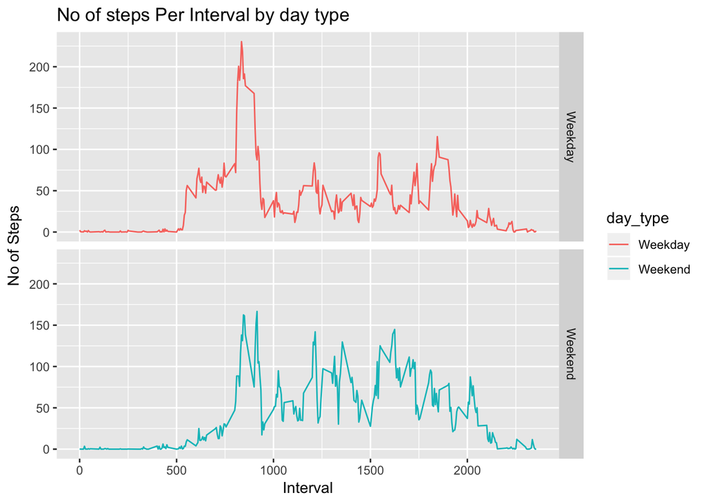

```r
activity$day_type <- as.factor(sapply(activity$date, week_day))
library(ggplot2)
new_daily_steps<- aggregate(steps ~ interval+day_type, activity, mean)
plt <- ggplot(new_daily_steps, aes(interval, steps)) +
    geom_line(stat = "identity", aes(colour = day_type)) +
    theme_gray() +
    facet_grid(day_type ~ ., scales="fixed", space="fixed") +
    labs(x="Interval", y=expression("No of Steps")) +
    ggtitle("No of steps Per Interval by day type")
print(plt)
```